# Pf3kv5_with_PNG

Somya Mehra

19/02/2019

## Data Preprocessing

Variants have been processed through a pipeline following GATK best practices. Indels have been filtered out; only SNPs remain. Variants lying in subtelomeric hypervariable, subtelomeric repeat, centromeric or internal hypervariable regions have been removed. Functional annotations have been made using snpEff.

We begin by extracting functional annotations for our variants

```r
metadata <- read.delim("pf3k_release_5_png_metadata_collated.txt",
                       header=TRUE, stringsAsFactors=FALSE, na.strings=c(""))

pf3kv5 <- seqOpen("pf3kv5_with_PNG.pass.snps.snpeff_ann.core.gds", readonly = FALSE)

# extract variant positions
var_annotations <- data.frame(chr = seqGetData(pf3kv5, "chromosome"),
                              pos = seqGetData(pf3kv5, "position"),
                              variant_id = seqGetData(pf3kv5, "variant.id"),
                              ref = as.character(ref(pf3kv5)))
nvar <- nrow(var_annotations)

# extract functional annotations -> multiple rows (one for each alternate allele)
# for multiallelic sites
snpeff_ann <- seqGetData(pf3kv5, "annotation/info/ANN")

func_annotations <- var_annotations[rep(1:nvar, times=snpeff_ann$length),] %>%
  mutate(snp_ann=snpeff_ann$data) %>%
  tidyr::separate(snp_ann, into=c("alt", "annotation", "impact", "gene_name", "gene_id",
                           "feature_type", "feature_id", "transcript_biotype", "rank",
                           "HGVS.c", "HGVS.p", "cDNA", "CDS", "AA"), sep="\\|", extra="drop") %>%
  select(-c("gene_name", "feature_id", "rank")) %>% distinct

readr::write_rds(func_annotations, "pf3kv5_functional_annotations.rds")
```

Our variant set contains 1485431 SNPs, segregated by chromosome as follows

SNP Counts by Chromosome

| chr | count |
| --- | --- |
| Pf3D7_01_v3 | 32990 |
| Pf3D7_02_v3 | 50648 |
| Pf3D7_03_v3 | 61581 |
| Pf3D7_04_v3 | 65612 |
| Pf3D7_05_v3 | 87161 |
| Pf3D7_06_v3 | 76660 |
| Pf3D7_07_v3 | 81313 |
| Pf3D7_08_v3 | 83673 |
| Pf3D7_09_v3 | 102224 |
| Pf3D7_10_v3 | 106900 |
| Pf3D7_11_v3 | 137242 |
| Pf3D7_12_v3 | 138788 |
| Pf3D7_13_v3 | 206208 |
| Pf3D7_14_v3 | 251190 |
| Pf3D7_API_v3 | 2581 |
| Pf_M76611 | 660 |

We have permitted multiallelic sites. The number of alternate alleles per site is summarised below

Alt alleles per site

| count | sites |
| --- | --- |
| 1 | 1415550 |
| 2 | 67843 |
| 3 | 2038 |

We now consider metadata (country, region, site and sequencing facility) for each sample. Samples without assigned countries are lab-strains (either genetic crosses or simulated COI), which we exclude from further analysis. We define the following regions:

- West Africa: Senegal, The Gambia, Guinea, Mali, Ghana, Nigeria
- Central Africa: DR of the Congo, Malawi
- South East Asia: Bangladesh, Cambodia, Vietnam, Thailand, Myanmar, Laos
- PNG: Papua New Guinea

```r
west_africa <- c("TheGambia", "Ghana", "Guinea", "Mali", "Nigeria", "Senegal")
central_africa <- c("DRoftheCongo", "Malawi")
se_asia <- c("Bangladesh", "Cambodia", "Laos", "Myanmar", "Thailand", "Vietnam")

metadata$region <- NA
metadata$region[metadata$country %in% west_africa] <- "WestAfrica"
metadata$region[metadata$country %in% central_africa] <- "CentralAfrica"
metadata$region[metadata$country %in% se_asia] <- "SEAsia"
metadata$region[metadata$country=="PNG"] <- "PNG"

metadata$sequencing <- "Sanger"
metadata[metadata$country=="Senegal" & !is.na(metadata$country),]$sequencing <- "BROAD"
metadata[substr(metadata$sample, 1, 3)=="PNG" & (!is.na(metadata$country)),]$sequencing <- "BROAD"


field_isolates <- metadata %>% filter(!is.na(country))
```

We have 2661 field isolates in total, segregating by region/country/site/sequencing facility as follows

Sample Counts by Site

| region | country | site | count |
| --- | --- | --- | --- |
| CentralAfrica | DRoftheCongo | Kinshasa | 113 |
| CentralAfrica | Malawi | Chikwawa | 317 |
| CentralAfrica | Malawi | Zomba | 52 |
| PNG | PNG | Alotau | 30 |
| PNG | PNG | Madang | 67 |
| PNG | PNG | Maprik | 52 |
| SEAsia | Bangladesh | Ramu | 50 |
| SEAsia | Cambodia | Pailin | 84 |
| SEAsia | Cambodia | PreahVihear | 104 |
| SEAsia | Cambodia | Pursat | 235 |
| SEAsia | Cambodia | Ratanakiri | 147 |
| SEAsia | Laos | Attapeu | 85 |
| SEAsia | Myanmar | BagoDivision | 60 |
| SEAsia | Thailand | MaeSot | 106 |
| SEAsia | Thailand | Ranong | 20 |
| SEAsia | Thailand | Sisakhet | 22 |
| SEAsia | Vietnam | BuDang | 1 |
| SEAsia | Vietnam | BuGiaMap | 64 |
| SEAsia | Vietnam | PhuocLong | 32 |
| WestAfrica | Ghana | Kassena | 549 |
| WestAfrica | Ghana | Kintampo | 68 |
| WestAfrica | Guinea | Nzerekore | 100 |
| WestAfrica | Mali | Bandiagara | 9 |
| WestAfrica | Mali | Faladje | 36 |
| WestAfrica | Mali | Kolle | 51 |
| WestAfrica | Nigeria | Ilorin | 5 |
| WestAfrica | Senegal | Thies | 133 |
| WestAfrica | Senegal | Velingara | 4 |
| WestAfrica | TheGambia | GM_Coastal | 65 |

Sample Counts by Sequencing Facility

| sequencing | count |
| --- | --- |
| BROAD | 151 |
| Sanger | 2510 |

We annotate our GDS file with metadata for each sample (region, country, site, sequencing facility)

```r
metadata <- metadata %>% arrange(sample)
# if(cnt.gdsn(index.gdsn(pf3kv5, "sample.annotation")) != 4) {
#  add.gdsn(index.gdsn(pf3kv5, "sample.annotation"),
#           name = "region", val = metadata$region)
#  add.gdsn(index.gdsn(pf3kv5, "sample.annotation"),
#           name = "country",val = metadata$country)
#  add.gdsn(index.gdsn(pf3kv5, "sample.annotation"),
#           name = "site", val = metadata$site)
#  add.gdsn(index.gdsn(pf3kv5, "sample.annotation"),
#           name = "sequencing_facility", val = metadata$sequencing)
# }
```

## Variant and Sample Filtration

We restrict our analysis to field isolates and variants on the 14 nuclear chromosomes only

```r
nuclear <- var_annotations %>% subset(chr!="Pf3D7_API_v3" & chr!="Pf_M76611")
seqSetFilter(pf3kv5, variant.id=nuclear$variant_id,
             sample.id=field_isolates$sample)
```

```
## # of selected samples: 2,661
## # of selected variants: 1,482,190
```

We consider the missingness per sample, and remove isolates with missingness rate >0.1

```r
missing_by_sample <- data.frame(sample=field_isolates$sample, missing=seqMissing(pf3kv5, per.variant = FALSE))
keep_samples <- as.character(missing_by_sample$sample[missing_by_sample$missing<=0.1])
field_isolates <- field_isolates %>% subset(sample %in% keep_samples)
seqResetFilter(pf3kv5)
```

```
## # of selected samples: 2,789
## # of selected variants: 1,485,431
```

```r
seqSetFilter(pf3kv5, variant.id=nuclear$variant_id,
             sample.id=keep_samples)
```

```
## # of selected samples: 2,463
## # of selected variants: 1,482,190
```

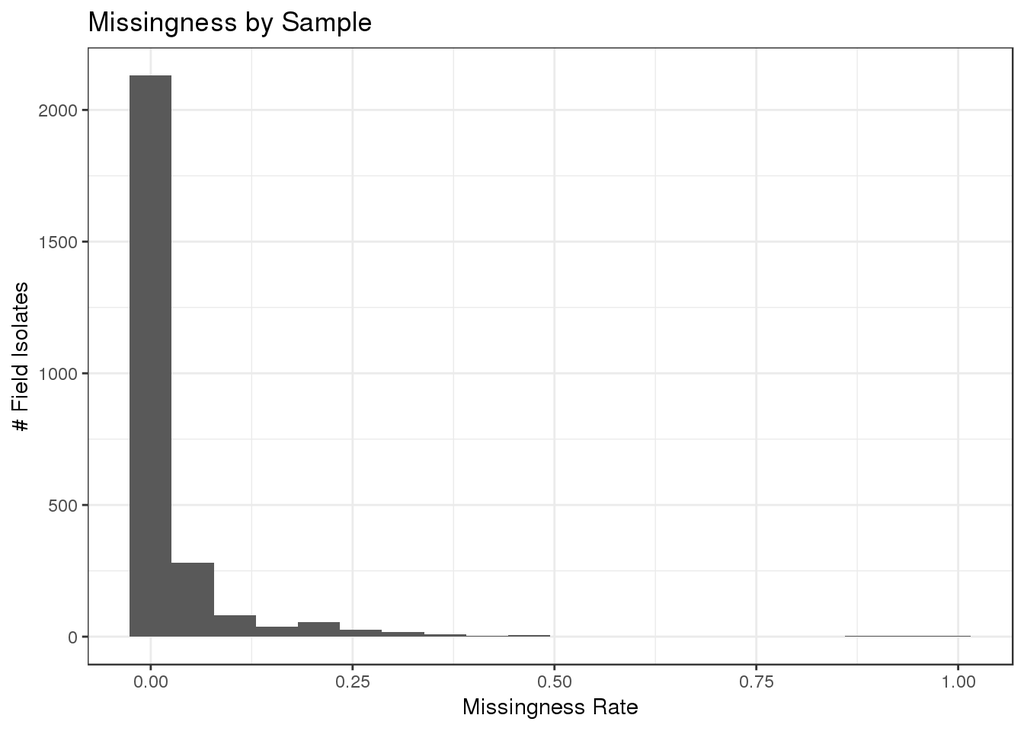

We have 2463 field isolates remaining after filtration, stratified geographically as follows

Sample Counts by Site

| region | country | site | count |
| --- | --- | --- | --- |
| CentralAfrica | DRoftheCongo | Kinshasa | 100 |
| CentralAfrica | Malawi | Chikwawa | 314 |
| CentralAfrica | Malawi | Zomba | 50 |
| PNG | PNG | Alotau | 29 |
| PNG | PNG | Madang | 52 |
| PNG | PNG | Maprik | 50 |
| SEAsia | Bangladesh | Ramu | 45 |
| SEAsia | Cambodia | Pailin | 84 |
| SEAsia | Cambodia | PreahVihear | 104 |
| SEAsia | Cambodia | Pursat | 231 |
| SEAsia | Cambodia | Ratanakiri | 146 |
| SEAsia | Laos | Attapeu | 85 |
| SEAsia | Myanmar | BagoDivision | 60 |
| SEAsia | Thailand | MaeSot | 104 |
| SEAsia | Thailand | Ranong | 20 |
| SEAsia | Thailand | Sisakhet | 21 |
| SEAsia | Vietnam | BuDang | 1 |
| SEAsia | Vietnam | BuGiaMap | 64 |
| SEAsia | Vietnam | PhuocLong | 32 |
| WestAfrica | Ghana | Kassena | 520 |
| WestAfrica | Ghana | Kintampo | 63 |
| WestAfrica | Guinea | Nzerekore | 100 |
| WestAfrica | Mali | Bandiagara | 8 |
| WestAfrica | Mali | Faladje | 27 |
| WestAfrica | Mali | Kolle | 34 |
| WestAfrica | Nigeria | Ilorin | 5 |
| WestAfrica | Senegal | Thies | 52 |
| WestAfrica | Senegal | Velingara | 4 |
| WestAfrica | TheGambia | GM_Coastal | 58 |

Sample Counts by Sequencing Facility

| sequencing | count |
| --- | --- |
| BROAD | 70 |
| Sanger | 2393 |

Variants have been annotated with the following quality metrics

```
## Annotation, INFO variable(s):
##     AC, A, Integer, Allele count in genotypes, for each ALT allele, in the same order as listed
##     AF, A, Float, Allele Frequency, for each ALT allele, in the same order as listed
##     AN, 1, Integer, Total number of alleles in called genotypes
##     BaseQRankSum, 1, Float, Z-score from Wilcoxon rank sum test of Alt Vs. Ref base qualities
##     DP, 1, Integer, Approximate read depth; some reads may have been filtered
##     DS, 0, Flag, Were any of the samples downsampled?
##     ExcessHet, 1, Float, Phred-scaled p-value for exact test of excess heterozygosity
##     FS, 1, Float, Phred-scaled p-value using Fisher's exact test to detect strand bias
##     InbreedingCoeff, 1, Float, Inbreeding coefficient as estimated from the genotype likelihoods per-sample when compared against the Hardy-Weinberg expectation
##     MQ, 1, Float, RMS Mapping Quality
##     MQRankSum, 1, Float, Z-score From Wilcoxon rank sum test of Alt vs. Ref read mapping qualities
##     QD, 1, Float, Variant Confidence/Quality by Depth
##     ReadPosRankSum, 1, Float, Z-score from Wilcoxon rank sum test of Alt vs. Ref read position bias
##     SOR, 1, Float, Symmetric Odds Ratio of 2x2 contingency table to detect strand bias
##     ANN, ., String, Functional annotations: 'Allele | Annotation | Annotation_Impact | Gene_Name | Gene_ID | Feature_Type | Feature_ID | Transcript_BioType | Rank | HGVS.c | HGVS.p | cDNA.pos / cDNA.length | CDS.pos / CDS.length | AA.pos / AA.length | Distance | ERRORS / WARNINGS / INFO'
```

Variant quality score recalibration has been conducted, and variants failing the following filters have already been removed

```
## Annotation, FILTER:
##     PASS, All filters passed, 1482190(100.0%)
##     LowQual, Low quality, 0(0.0%)
##     highExcessHet, Set if true: ExcessHet>54.69, 0(0.0%)
##     lowQD, Set if true: QD<2.0, 0(0.0%)
##     lowMQ, Set if true: MQ<30.0, 0(0.0%)
##     highFS, Set if true: FS>100.0, 0(0.0%)
##     highSOR, Set if true: SOR>7.5, 0(0.0%)
##     lowReadPosRankSum, Set if true: ReadPosRankSum<-5.0, 0(0.0%)
##     lowInbreedingCoeff, Set if true: InbreedingCoeff<-0.8, 0(0.0%)
##     lowMQRankSum, Set if true: MQRankSum<-5.0, 0(0.0%)
```

We consider various GATK metrics to see whether further hard-filtration is necessary

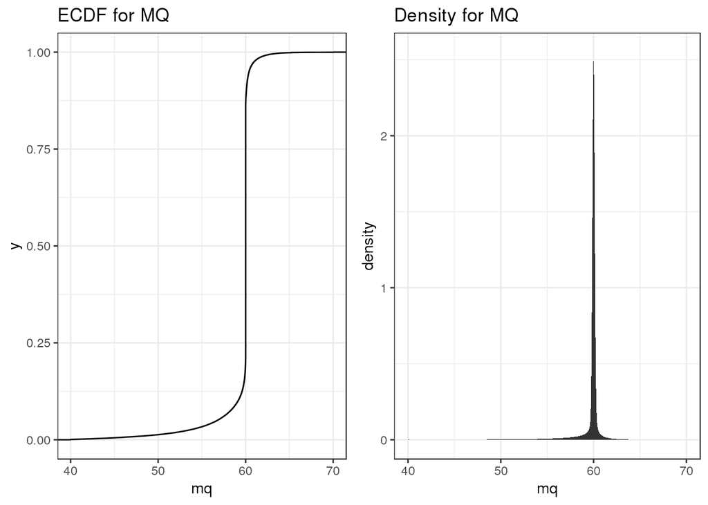

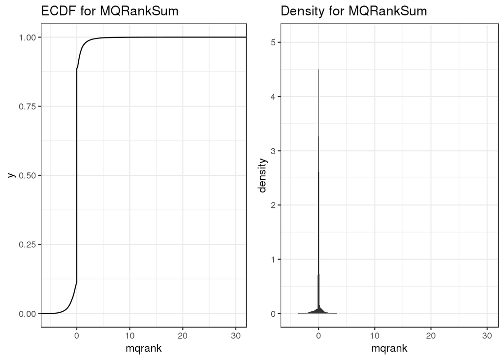

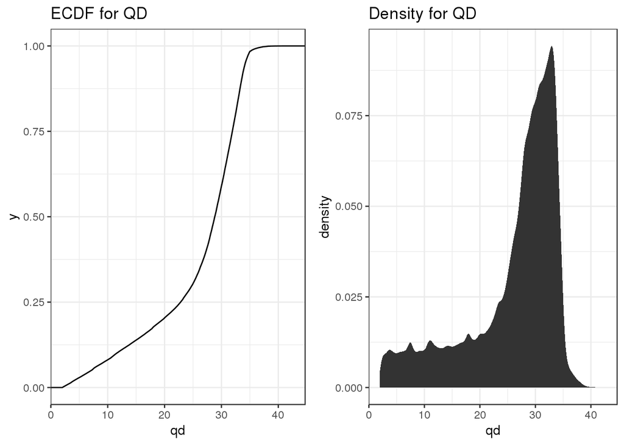

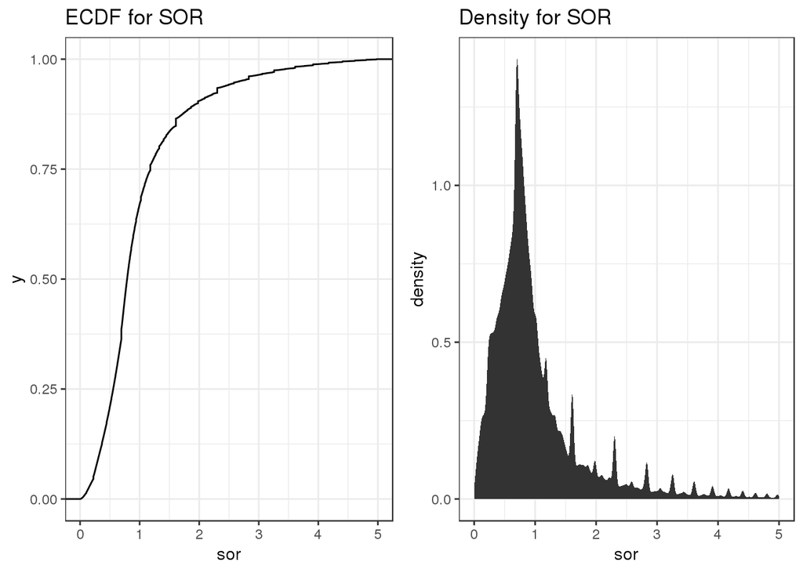

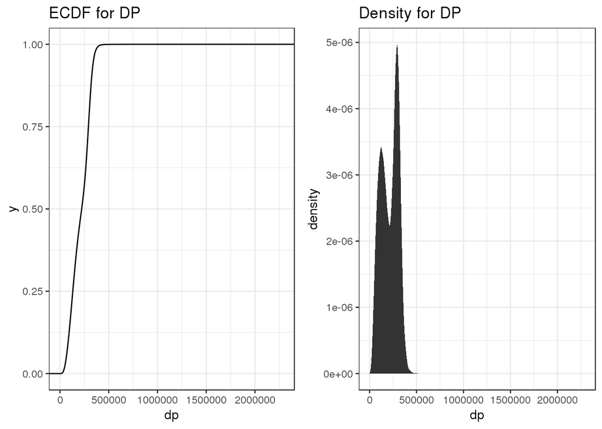

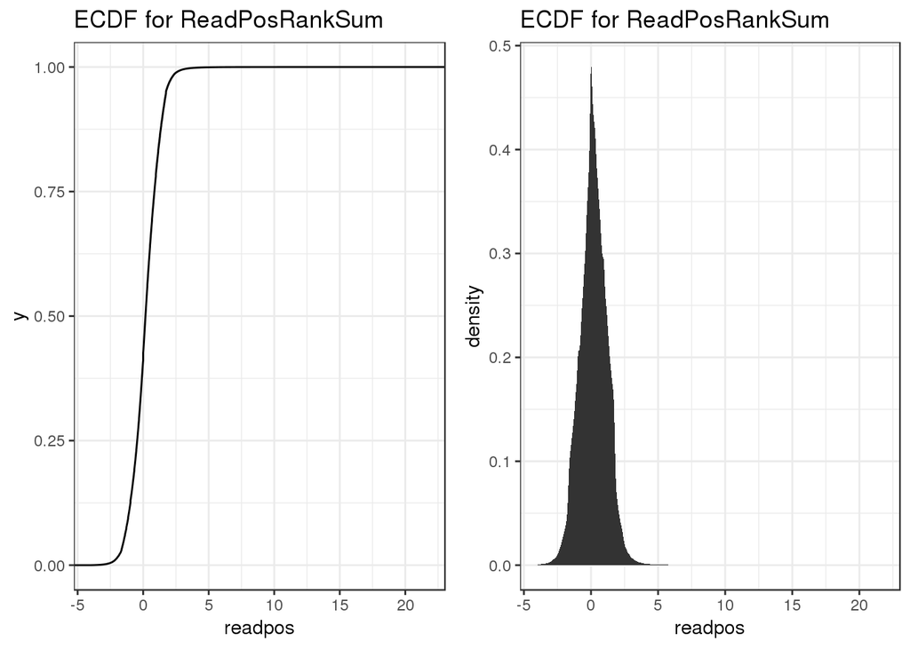

We apply the following hard-filters:

- QD > 20
- MQ > 50
- MQRankSum > -2 (if annotated)
- SOR < 1
- -4 < ReadPosRankSum < 4 (if annotated)

Note that there are 140 variants without MQ, 465554 without MQRankSum, 469376 without ReadPosRankSum and 676 without QD annotations.

```r
hard_filtered <- gatk_metrics %>%
  subset(qd>20 & sor<1 & mq>50 &
           (mqrank>-2 | is.nan(mqrank)) &
           ((readpos>-4 & readpos<4) | is.nan(readpos)))
```

770591 SNPs are retained after hard-filtering by GATK metrics. We now consider the missingness per site, and remove sites with missingness rate >0.1.

```r
seqResetFilter(pf3kv5)
```

```
## # of selected samples: 2,789
## # of selected variants: 1,485,431
```

```r
seqSetFilter(pf3kv5, variant.id=hard_filtered$variant.id,
             sample.id=keep_samples)
```

```
## # of selected samples: 2,463
## # of selected variants: 770,591
```

```r
missing_per_snp <- data.frame(var=hard_filtered$variant.id, missing=seqMissing(pf3kv5, per.variant = TRUE))
keep_low_missing_var <- missing_per_snp$var[missing_per_snp$missing<=0.1]
hard_filtered <- hard_filtered %>% subset(variant.id %in% keep_low_missing_var)
```

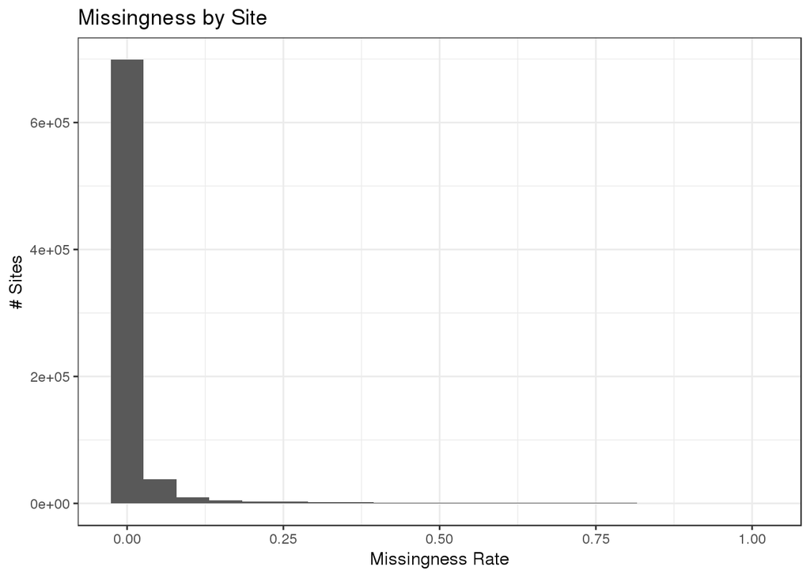

742365 SNPs are retained after hard filtering by GATK metrics and missingness.

```r
seqResetFilter(pf3kv5)
```

```
## # of selected samples: 2,789
## # of selected variants: 1,485,431
```

```r
seqSetFilter(pf3kv5, variant.id=hard_filtered$variant.id,
             sample.id=keep_samples)
```

```
## # of selected samples: 2,463
## # of selected variants: 742,365
```

```r
func_annotations %>% subset(variant_id %in% hard_filtered$variant.id) %>% readr::write_rds("pf3kv5_functional_annotations_filtered.rds")
```

The final set of SNPs segregates across chromosomes as follows

Hard-filtered SNP counts

| chr | count |
| --- | --- |
| Pf3D7_01_v3 | 16100 |
| Pf3D7_02_v3 | 25432 |
| Pf3D7_03_v3 | 30244 |
| Pf3D7_04_v3 | 33723 |
| Pf3D7_05_v3 | 43241 |
| Pf3D7_06_v3 | 38174 |
| Pf3D7_07_v3 | 42358 |
| Pf3D7_08_v3 | 41796 |
| Pf3D7_09_v3 | 50248 |
| Pf3D7_10_v3 | 52970 |
| Pf3D7_11_v3 | 68240 |
| Pf3D7_12_v3 | 69087 |
| Pf3D7_13_v3 | 103682 |
| Pf3D7_14_v3 | 127070 |

SNP densities across 5kb bins are shown below

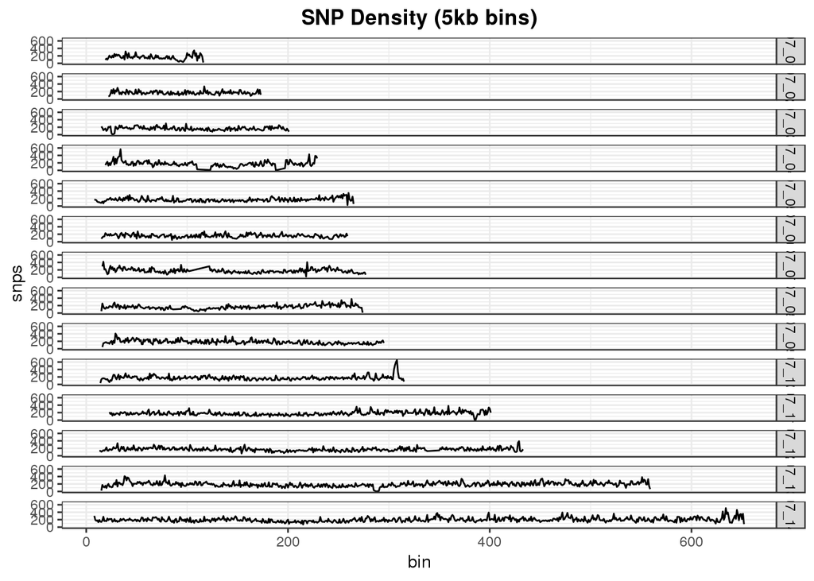

A break-down of the number of alternate alleles per site is given below

Alt alleles per site

| count | sites |
| --- | --- |
| 1 | 697275 |
| 2 | 43623 |
| 3 | 1467 |

## FWS and MAF Estimates

We stratify our hard-filtered data by country and sequentially apply the following filters:

1. Extract polymorphic SNPs i.e. MAF>0
2. Extract SNPs that are covered by >=5 reads in at least 90% of samples
3. Extract samples that have 90% of filtered SNPs covered by >=5 reads

We then calculate FWS and MAF using these by-country datasets.

```
## # of selected samples: 2,789
## # of selected variants: 1,485,431
## ## Now running TheGambia estimates
## # of selected samples: 58
## # of selected variants: 742,365
## # of selected variants: 78,343
## # of selected samples: 57
## # of selected variants: 75,392
```

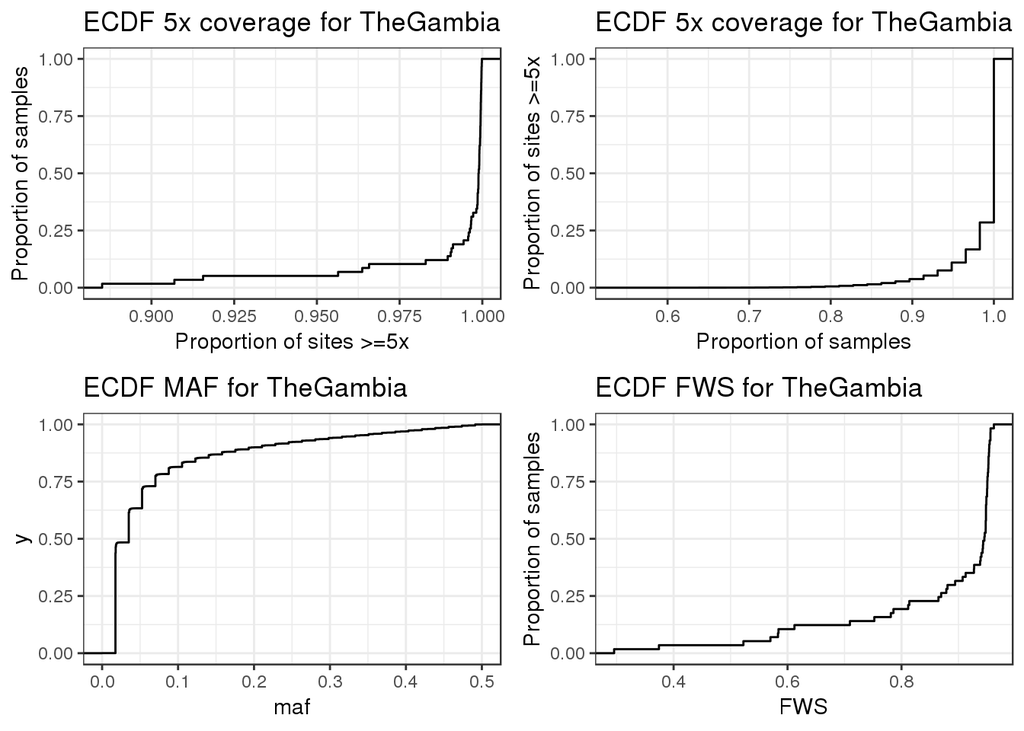

```
## # of selected samples: 2,789
## # of selected variants: 1,485,431
## ## Now running Guinea estimates
## # of selected samples: 100
## # of selected variants: 742,365
## # of selected variants: 124,771
## # of selected samples: 100
## # of selected variants: 123,879
```

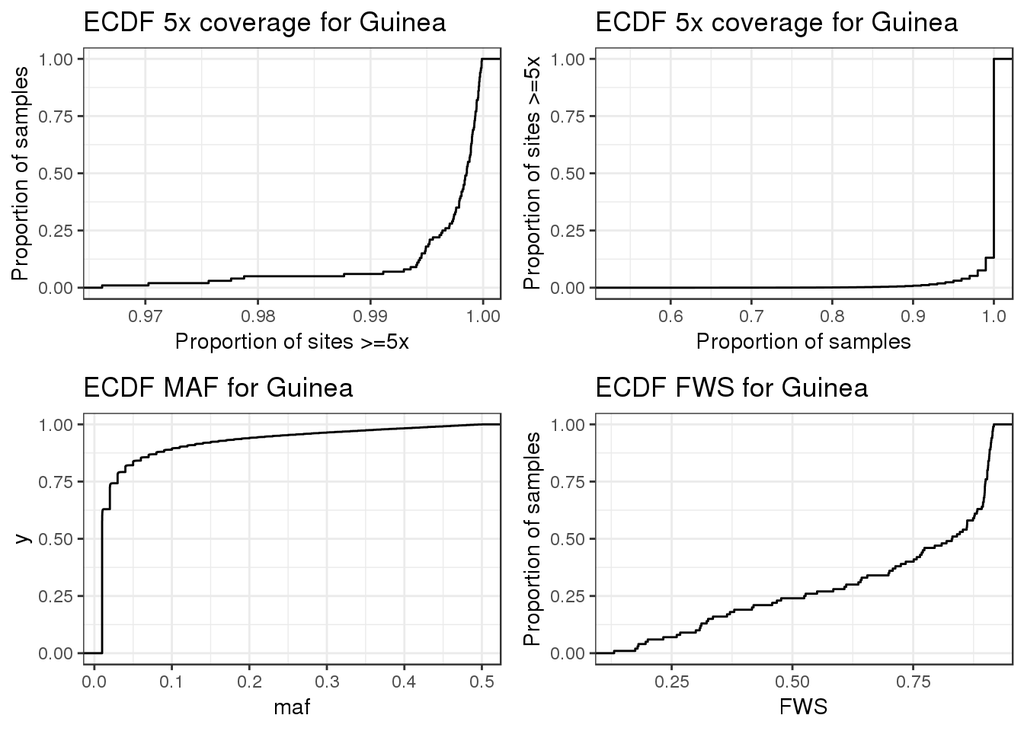

```
## # of selected samples: 2,789
## # of selected variants: 1,485,431
## ## Now running Ghana estimates
## # of selected samples: 583
## # of selected variants: 742,365
## # of selected variants: 378,843
## # of selected samples: 557
## # of selected variants: 355,378
```

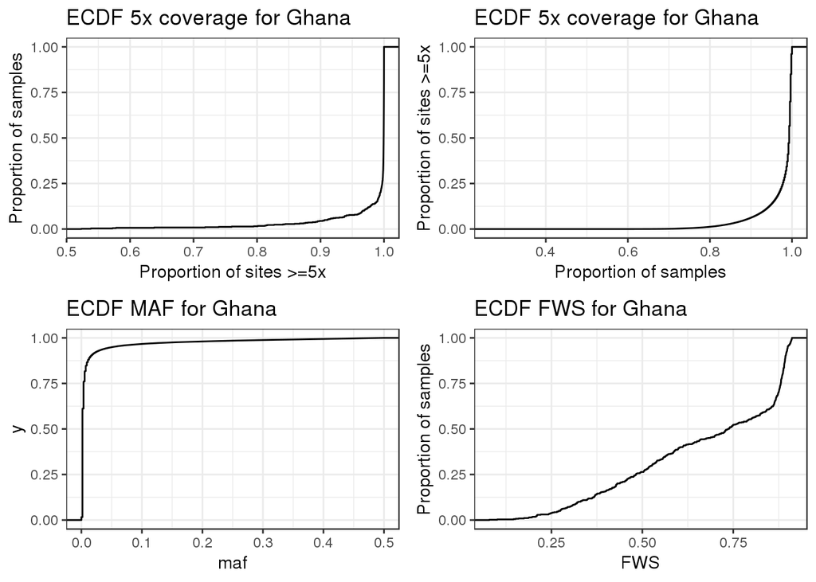

```
## # of selected samples: 2,789
## # of selected variants: 1,485,431
## ## Now running Mali estimates
## # of selected samples: 69
## # of selected variants: 742,365
## # of selected variants: 90,841
## # of selected samples: 69
## # of selected variants: 75,450
```

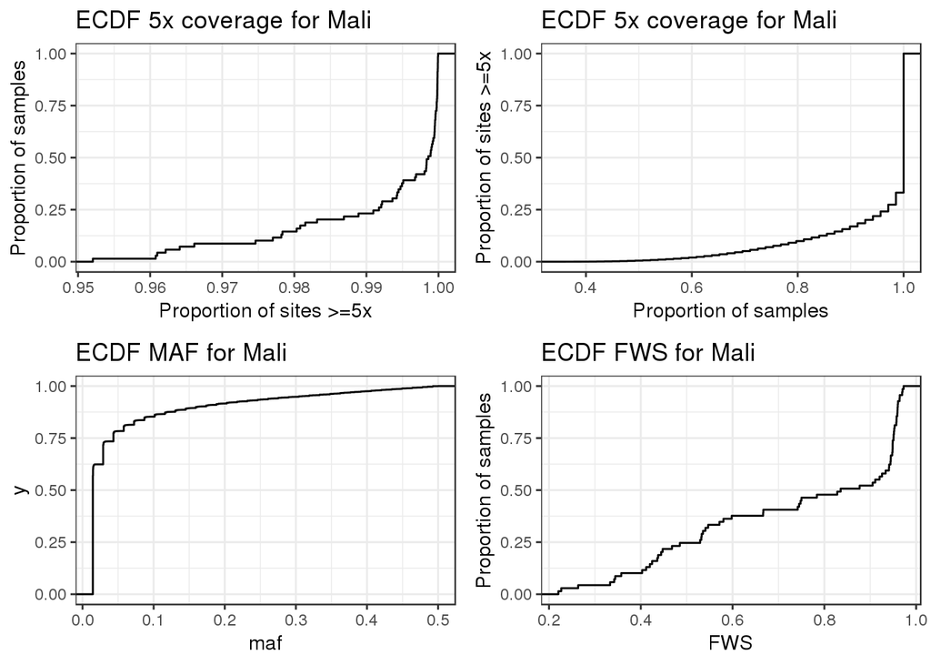

```
## # of selected samples: 2,789
## # of selected variants: 1,485,431
## ## Now running Nigeria estimates
## # of selected samples: 5
## # of selected variants: 742,365
## # of selected variants: 19,906
## # of selected samples: 5
## # of selected variants: 16,148
```

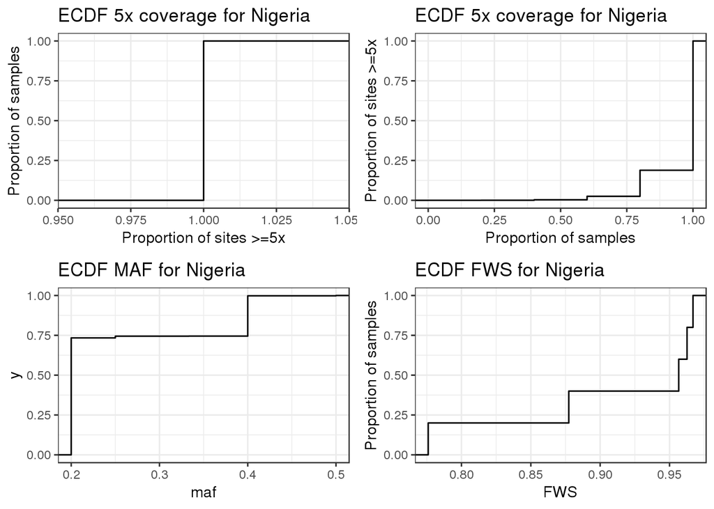

```
## # of selected samples: 2,789
## # of selected variants: 1,485,431
## ## Now running Senegal estimates
## # of selected samples: 56
## # of selected variants: 742,365
## # of selected variants: 91,147
## # of selected samples: 55
## # of selected variants: 81,792
```

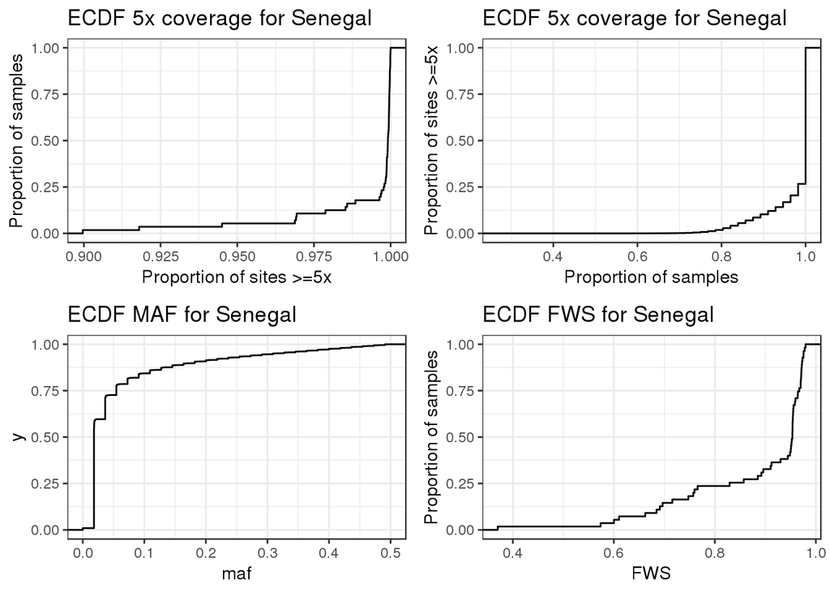

```
## # of selected samples: 2,789
## # of selected variants: 1,485,431
## ## Now running Thailand estimates
## # of selected samples: 145
## # of selected variants: 742,365
## # of selected variants: 51,518
## # of selected samples: 140
## # of selected variants: 49,506
```

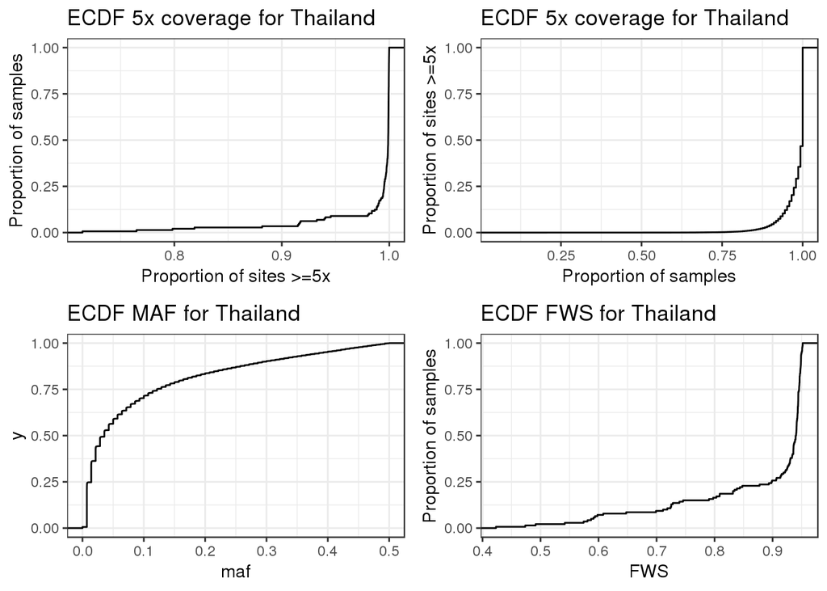

```
## # of selected samples: 2,789
## # of selected variants: 1,485,431
## ## Now running Cambodia estimates
## # of selected samples: 565
## # of selected variants: 742,365
## # of selected variants: 85,478
## # of selected samples: 527
## # of selected variants: 76,305
```

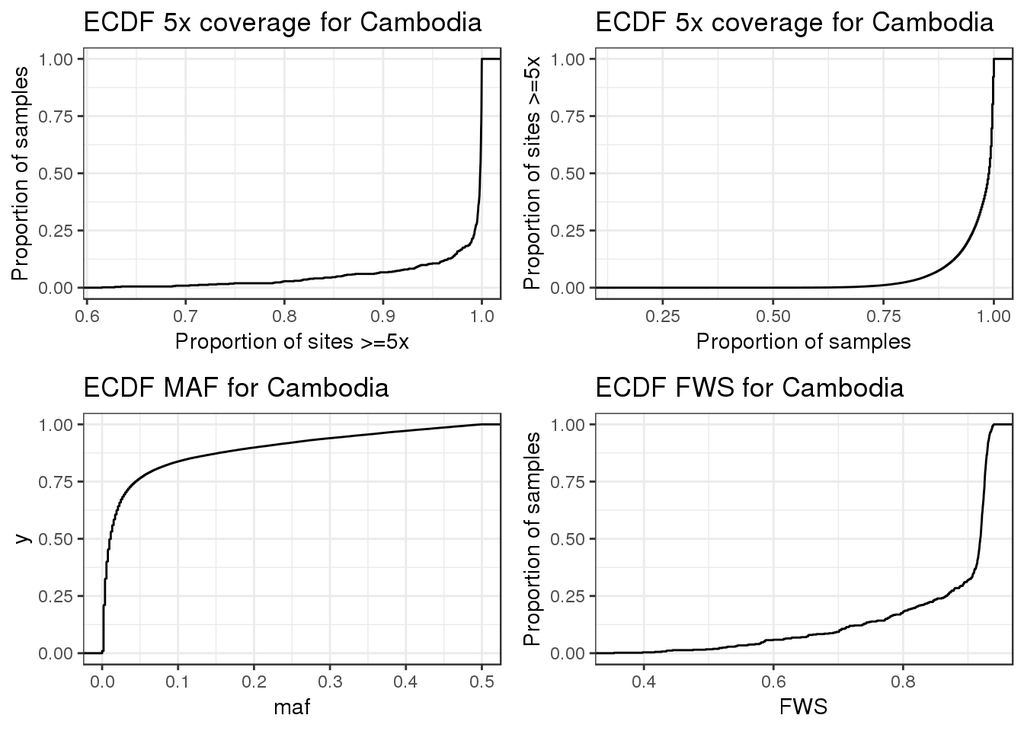

```
## # of selected samples: 2,789
## # of selected variants: 1,485,431
## ## Now running Bangladesh estimates
## # of selected samples: 45
## # of selected variants: 742,365
## # of selected variants: 57,969
## # of selected samples: 45
## # of selected variants: 50,182
```

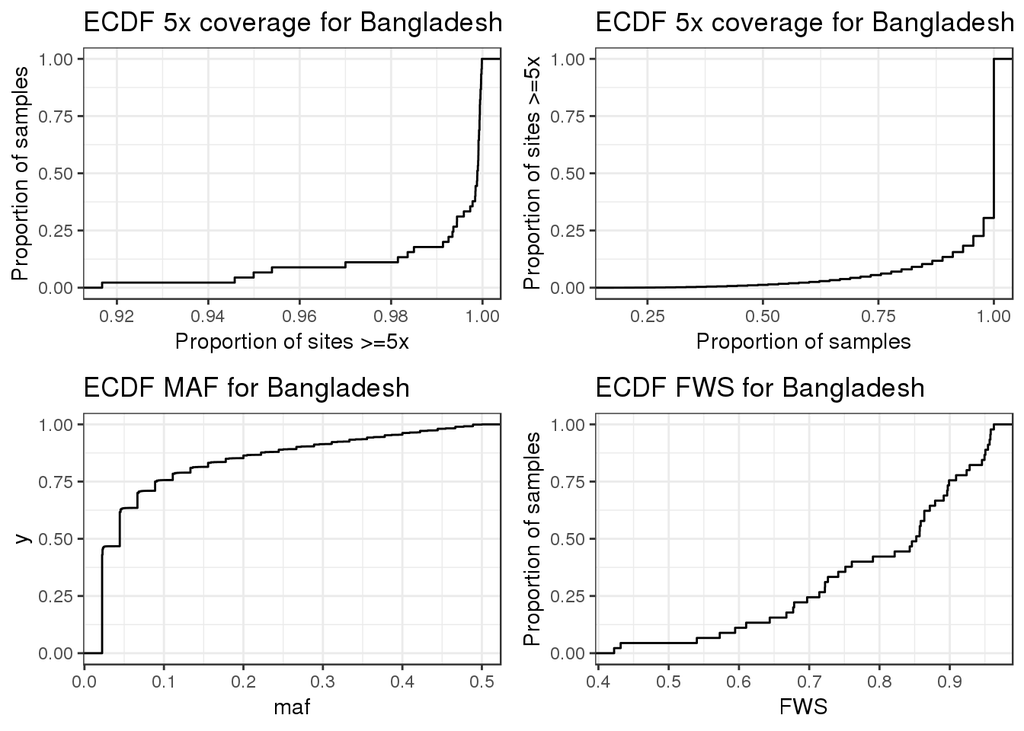

```
## # of selected samples: 2,789
## # of selected variants: 1,485,431
## ## Now running Vietnam estimates
## # of selected samples: 97
## # of selected variants: 742,365
## # of selected variants: 53,198
## # of selected samples: 97
## # of selected variants: 50,874
```

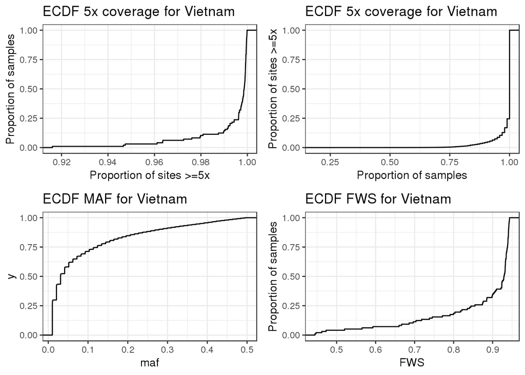

```
## # of selected samples: 2,789
## # of selected variants: 1,485,431
## ## Now running Myanmar estimates
## # of selected samples: 60
## # of selected variants: 742,365
## # of selected variants: 43,946
## # of selected samples: 59
## # of selected variants: 40,886
```

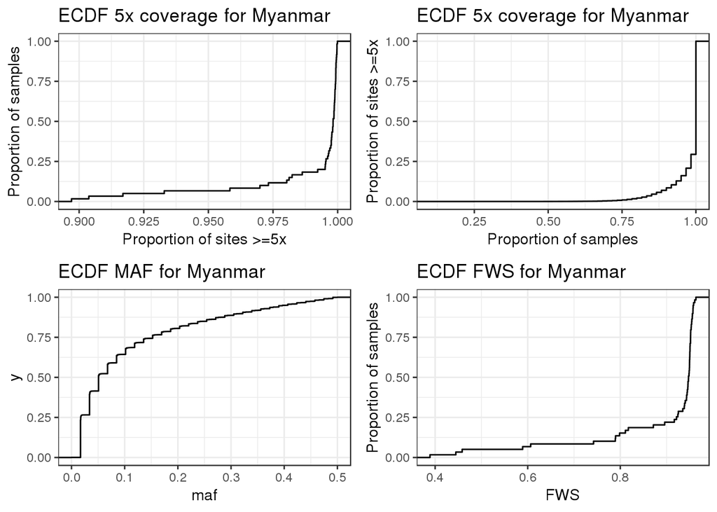

```
## # of selected samples: 2,789
## # of selected variants: 1,485,431
## ## Now running Laos estimates
## # of selected samples: 85
## # of selected variants: 742,365
## # of selected variants: 58,735
## # of selected samples: 84
## # of selected variants: 57,136
```

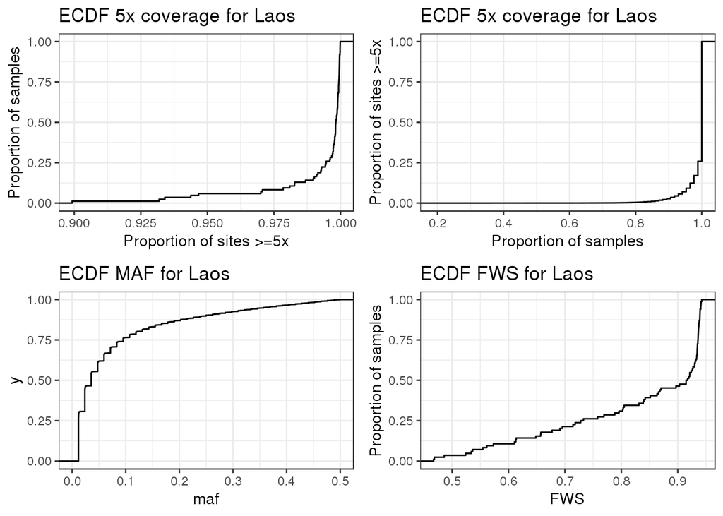

```
## # of selected samples: 2,789
## # of selected variants: 1,485,431
## ## Now running PNG estimates
## # of selected samples: 131
## # of selected variants: 742,365
## # of selected variants: 62,137
## # of selected samples: 127
## # of selected variants: 57,874
```

[3 more figures not shown]

```r
pf3kv5_stats <- list()

maf_by_site <- function(pf3kv5) {
  seqApply(pf3kv5, "genotype",
           FUN=function(x) {raf=mean(x==0L, na.rm=TRUE); return(min(raf, 1-raf))},
           as.is="double", margin="by.variant") %>% return
}

for (region in unique(field_isolates$region)) {
  pf3kv5_stats[[region]] <- list()
  countries <- unique(field_isolates$country[field_isolates$region == region])
  for (country in countries) {
    seqResetFilter(pf3kv5)
    pf3kv5_stats[[region]][[country]] <- list()
    cat(paste("## Now running", country, "estimates\n"))
    # filter samples from country of interest
    samples <- field_isolates$sample[field_isolates$country == country]
    seqSetFilter(pf3kv5, sample.id = samples, variant.id = hard_filtered$variant.id)
    # keep variants that are polymorphic in country of interest
    maf_country <- maf_by_site(pf3kv5)
    keep_polymorphic_var <- hard_filtered$variant.id[maf_country>0 & !is.na(maf_country)]
    seqSetFilter(pf3kv5, variant.id=keep_polymorphic_var)
    # keep SNPs that are covered by >=5 reads in 90% of samples
    cov_depth <- seqGetData(pf3kv5, "annotation/format/DP")$data
    var_5x_cov <- colSums(cov_depth>=5)/nrow(cov_depth)
    keep_polymorphic_5x_cov <- keep_polymorphic_var[var_5x_cov>=0.9]
    # keep samples that have 90% of filtered SNPs covered by >=5 reads
    sample_5x_cov <- rowSums(cov_depth[,var_5x_cov>=0.9]>=5)/sum(var_5x_cov>=0.9)
    keep_sample_5x <- samples[sample_5x_cov>=0.9]
    seqSetFilter(pf3kv5, variant.id=keep_polymorphic_5x_cov, sample.id=keep_sample_5x)
    # compute MAF for filtered sites + samples
    pf3kv5_stats[[region]][[country]]$maf <- data.frame(variant.id=keep_polymorphic_5x_cov,
                                                        maf=maf_by_site(pf3kv5))
    # compute FWS for filtered sites + samples
    pf3kv5_stats[[region]][[country]]$fws <- data.frame(sample.id=keep_sample_5x,
                                                        fws=getFws(pf3kv5))
    # generate ECDF curves for coverage, MAF and FWS
    maf_plot <- ggplot(pf3kv5_stats[[region]][[country]]$maf, aes(x=maf)) +
      stat_ecdf() + ggtitle(paste("ECDF MAF for", country)) + theme_bw()
    sample_cov_plot <- ggplot(data.frame(cov=sample_5x_cov), aes(x=cov)) +
      stat_ecdf() + ggtitle(paste("ECDF 5x coverage for", country)) + xlab("Proportion of sites >=5x") +
      ylab("Proportion of samples") + theme_bw()
    var_cov_plot <- ggplot(data.frame(cov=var_5x_cov), aes(x=cov)) +
      stat_ecdf() + ggtitle(paste("ECDF 5x coverage for", country)) + xlab("Proportion of samples") +
      ylab("Proportion of sites >=5x") + theme_bw()
    fws_plot <- ggplot(pf3kv5_stats[[region]][[country]]$fws, aes(x=fws)) +
      stat_ecdf() + ggtitle(paste("ECDF FWS for", country)) + xlab("FWS") +
      ylab("Proportion of samples") + theme_bw()

    print(plot_grid(sample_cov_plot, var_cov_plot, maf_plot, fws_plot))
  }
}
```

```r
readr::write_rds(pf3kv5_stats, "pf3kv5_stats.rds")
```

## MOI Estimates

We determine MOI by considering FWS values

- MOI = 1: FWS > 0.95
- MOI = 2: 0.80 < FWS <= 0.95
- MOI > 2: FWS <= 0.80

```r
fws <- data.frame(sample.id=character(0), fws=numeric(0))
for (region in names(pf3kv5_stats)) {
  for (country in names(pf3kv5_stats[[region]])) {
    fws <- pf3kv5_stats[[region]][[country]]$fws %>%
      mutate(country=country, region=region,
             moi=ifelse(fws>0.95, 1, ifelse(fws>0.8, 2, NA))) %>% rbind(fws)
  }
}
readr::write_rds(fws, "pf3kv5_fws.rds")
```

We compare the distribution of FWS values across geographic strata

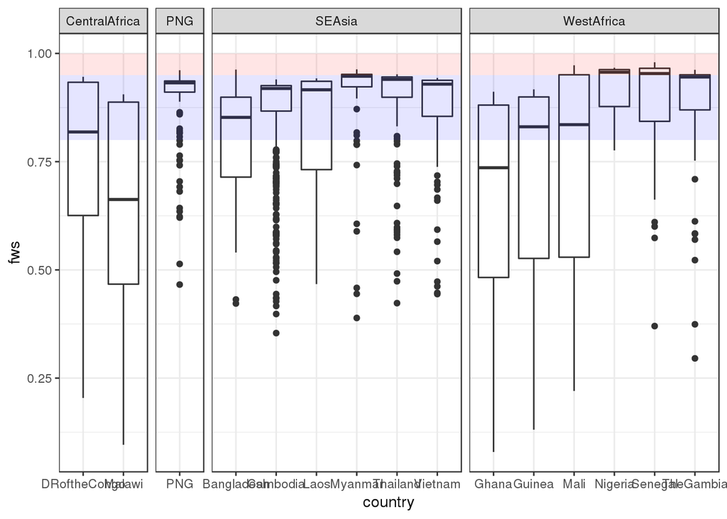

A summary of MOI across our samples is given below. NA indicates indeterminate MOI > 2.

MOI by Country

| moi | count |
| --- | --- |
| 1 | 108 |
| 2 | 1391 |
| NA | 878 |

MOI by Country

| region | country | moi | count |
| --- | --- | --- | --- |
| CentralAfrica | DRoftheCongo | 2 | 53 |
| CentralAfrica | DRoftheCongo | NA | 44 |
| CentralAfrica | Malawi | 2 | 142 |
| CentralAfrica | Malawi | NA | 216 |
| PNG | PNG | 1 | 2 |
| PNG | PNG | 2 | 110 |
| PNG | PNG | NA | 15 |
| SEAsia | Bangladesh | 1 | 6 |
| SEAsia | Bangladesh | 2 | 20 |
| SEAsia | Bangladesh | NA | 19 |
| SEAsia | Cambodia | 2 | 433 |
| SEAsia | Cambodia | NA | 94 |
| SEAsia | Laos | 2 | 58 |
| SEAsia | Laos | NA | 26 |
| SEAsia | Myanmar | 1 | 22 |
| SEAsia | Myanmar | 2 | 28 |
| SEAsia | Myanmar | NA | 9 |
| SEAsia | Thailand | 1 | 7 |
| SEAsia | Thailand | 2 | 110 |
| SEAsia | Thailand | NA | 23 |
| SEAsia | Vietnam | 2 | 79 |
| SEAsia | Vietnam | NA | 18 |
| WestAfrica | Ghana | 2 | 248 |
| WestAfrica | Ghana | NA | 309 |
| WestAfrica | Guinea | 2 | 53 |
| WestAfrica | Guinea | NA | 47 |
| WestAfrica | Mali | 1 | 18 |
| WestAfrica | Mali | 2 | 18 |
| WestAfrica | Mali | NA | 33 |
| WestAfrica | Nigeria | 1 | 3 |
| WestAfrica | Nigeria | 2 | 1 |
| WestAfrica | Nigeria | NA | 1 |
| WestAfrica | Senegal | 1 | 32 |
| WestAfrica | Senegal | 2 | 10 |
| WestAfrica | Senegal | NA | 13 |
| WestAfrica | TheGambia | 1 | 18 |
| WestAfrica | TheGambia | 2 | 28 |
| WestAfrica | TheGambia | NA | 11 |

## Appendix

```r
showfile.gds(closeall=TRUE)
```

```
##                                                                                                        FileName
## 1 /stornext/General/data/academic/lab_barry/Somya/Pf3k_PNG/report/pf3kv5_with_PNG.pass.snps.snpeff_ann.core.gds
##   ReadOnly  State
## 1    FALSE closed
```